# PEC2_RNASeq

Silvia Garcia Lezcano

6/4/2020

## PEC2: Análisis de datos Ómicos. Análisis de datos de RNAseq

# Estudiante: Silvia Garcia Lezcano

Repositorio en GitHub: https://github.com/silviatgl/PEC2_SILVIA_GARCIA.git

# Objetivos:

# Métodos

En un ambito normal partiríamos de “base call files” que es el archivo más crudo de un secuenciador. Primero haríamos el demultiplexado para obtener los FastQs de cada una de las muestras usando un software como bcl2fastQ. Lo siguiente que habría que hacer sería alinear las lecturas contra el genoma de referencia, eliminar los duplicados de PCR y duplicados ópticos. Esto dependería mucho del método utilizado para preparar las librerías de RNA y de la máquina usada.Una vez realizado el alineamiento y este filtrado de calidad inicial, obtendríamos los archivos bam. En la figura 1 resumimos el proceso de análisis de datos que tenemos que hacer antes de empezar con el análisis mostrado en este análisis. Una vez tuvieramos los bam y los datos de las muestras, podríamos comenzar a analizar los datos con el paquete DESeq2. En el caso específico de este análisis empezamos directamente con un archivo de conteo, que se generaría a partir de los bams, básicamente contando cuantas copias únicas de cada tránscrito se han secuenciado en una carrera, más un archivo en el cual tenemos un resumen de las muestras y sus condiciones de análisis

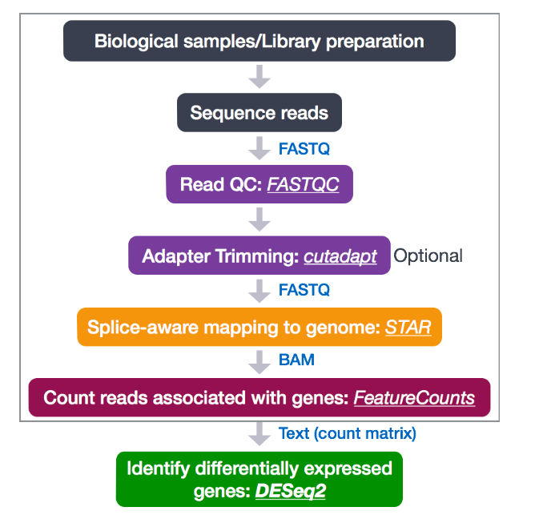

*Figura 1: Pipeline de análisis de datos crudos desde el ouptut del secuenciador a el input de DESeq2*

# Selección de los datos y carga de los datos:

Primero cargamos ambos csv, tenemos que tener cuidado al ver como están organizados. Después hacemos una selección aleatoria de 10 valores de cada uno de los grupos del archivo targets:

```r
library(dplyr)
counts <- read.table("~/Silvia/Omicas/archivos targets y counts/counts.csv", row.names = 1, sep = ";", header = TRUE, check.names = FALSE)
targets <- read.csv("~/Silvia/Omicas/archivos targets y counts/targets.csv")
#eliminamos las dos primeras columnas que no tienen utilidad
targets <- targets [,-2]
#filtramos 10 muestras aleatorias para cada grupo
targets10 <- targets %>% filter(Group %in% c("NIT", "ELI", "SFI")) %>% group_by(Group) %>% sample_n(., 10)
```

El siguiente paso es seleccionar las columnas correspondientes en el archivo “counts.csv”, pero esto no nimio,ya que tenemos que asegurarnos de que tenemos el data frame importado de la manera correcta, para poder filtrarlo sin que se corte la primera columna, tenemos que incluirla como `rownames`. Despues podemos proceder a realizar la intersección de los datos.

```r
counts10<- counts[intersect(names(counts), targets10$Sample_Name)]
library(knitr)
kable(head(counts10))
```

|  | GTEX-11DXY-0426-SM-5H12R | GTEX-11DZ1-2726-SM-5A5KH | GTEX-11EQ9-0626-SM-5A5K1 | GTEX-11GSO-0626-SM-5A5LW | GTEX-11O72-2326-SM-5BC7H | GTEX-11XUK-0226-SM-5EQLW | GTEX-131XG-0226-SM-5IFG1 | GTEX-132AR-1126-SM-5P9GA | GTEX-1399T-0126-SM-5KM15 | GTEX-13FLV-0226-SM-5J2OF | GTEX-13NZ9-1126-SM-5MR37 | GTEX-13O1R-0826-SM-5J2MB | GTEX-13QJC-0826-SM-5RQKC | GTEX-13VXT-0626-SM-5SIA1 | GTEX-146FR-0326-SM-5SI8U | GTEX-14ABY-0926-SM-5Q5DY | GTEX-14AS3-0226-SM-5Q5B6 | GTEX-14BMU-0226-SM-5S2QA | GTEX-PLZ4-1226-SM-2I5FE | GTEX-QEL4-0726-SM-3GIJ5 | GTEX-QLQ7-0726-SM-2I5G2 | GTEX-TSE9-0626-SM-3DB8B | GTEX-U8T8-2326-SM-3DB96 | GTEX-X15G-0526-SM-3NMB7 | GTEX-YFC4-2626-SM-5P9FQ | GTEX-YFCO-0326-SM-4W1ZP | GTEX-YJ89-0726-SM-5P9F7 | GTEX-ZE7O-1126-SM-57WC8 | GTEX-ZYVF-1126-SM-5E458 | … |
| --- | --- | --- | --- | --- | --- | --- | --- | --- | --- | --- | --- | --- | --- | --- | --- | --- | --- | --- | --- | --- | --- | --- | --- | --- | --- | --- | --- | --- | --- | --- |
| ENSG00000223972.4 | 0 | 0 | 6 | 0 | 0 | 0 | 0 | 0 | 2 | 5 | 0 | 3 | 0 | 1 | 0 | 1 | 0 | 2 | 5 | 4 | 6 | 3 | 3 | 26 | 1 | 7 | 4 | 1 | 2 | … |
| ENSG00000227232.4 | 663 | 525 | 640 | 544 | 633 | 419 | 325 | 907 | 855 | 1572 | 1002 | 460 | 825 | 899 | 514 | 775 | 834 | 423 | 489 | 511 | 666 | 1704 | 841 | 810 | 1472 | 1000 | 1325 | 713 | 838 | … |
| ENSG00000243485.2 | 0 | 0 | 4 | 0 | 2 | 0 | 1 | 1 | 2 | 1 | 1 | 0 | 1 | 0 | 1 | 2 | 1 | 0 | 1 | 2 | 3 | 1 | 1 | 6 | 1 | 2 | 1 | 2 | 1 | … |
| ENSG00000237613.2 | 0 | 1 | 3 | 3 | 1 | 1 | 2 | 1 | 2 | 1 | 0 | 1 | 0 | 1 | 2 | 0 | 1 | 0 | 3 | 2 | 3 | 1 | 0 | 7 | 0 | 5 | 0 | 0 | 4 | … |
| ENSG00000268020.2 | 0 | 0 | 1 | 0 | 0 | 0 | 0 | 0 | 1 | 2 | 0 | 2 | 0 | 1 | 1 | 0 | 0 | 2 | 2 | 4 | 2 | 0 | 0 | 4 | 0 | 3 | 2 | 0 | 1 | … |
| ENSG00000240361.1 | 3 | 0 | 3 | 0 | 1 | 0 | 2 | 0 | 0 | 2 | 1 | 0 | 1 | 1 | 1 | 0 | 0 | 1 | 1 | 1 | 4 | 0 | 0 | 6 | 1 | 5 | 1 | 0 | 1 | … |

¡Hay que tener en cuenta que las muestras no están en el mismo orden con respecto al archivo de targets! Esto ha generado un primer análisis que no tenía sentido y hemos tenido que repetir todo el proceso hasta que hemos entendido que este era el problema gracias al training de DESeq2 de Bioconductor(Love,2020).

Es absolutamente crítico que las columnas de la matriz de conteo y las filas de los datos de la columna (información sobre muestras) estén en el mismo orden. DESeq2 no hará conjeturas sobre qué columna de la matriz de conteo pertenece a qué fila de los datos de la columna, estos deben proporcionarse a DESeq2 ya en un orden consistente.Por tanto debemos organizar las muestras en el archivo counts en el mismo orden que aparecen en el de targets:

```r
#Primero les cambiamos el nombre para trabajar con mayor comodidad:
coldata<-targets10
countdata<-counts10

# luego usamos la librería data.table para ordenar nuestras columnas del archivo de counts en el orden de la columna de Sample_Name

library(data.table)
setcolorder(countdata, as.character(coldata$Sample_Name))

#Eliminamos el ".X" de los nombres de ENSEMBL para evitar problemas a la hora de anotar los tránscritos:

rownames(countdata) <- sub("\\.\\d$","",rownames(countdata))
```

Ahora ya tendríamos los datos listos para empezar a trabajar con ellos